# How has the NBA changed over the years

Cesar Macias

2024-04-18

## Introduction

There is a debate within the basketball community and fans of the NBA. Fans cannot decide whether or not the rise of scoring within the NBA is related to the overall team scoring or the individual player. Some think that it is the former while others think that it is the latter. Others, believe that there is some correlation between two. We know that scoring had increased over the years, especially during the last decade. The question is: by how much and how? And whether there is a correlation between teams and the players.

## Our Questions

Main Questions: How has NBA team offenses changed over the years? How different was it 20, 10, and 5 years ago compared to now?

Other Questions: Are basketball games in the NBA played at a faster pace? How are the games being played faster? Are teams shooting more three pointers? How has the NBA changed for the individual players? Are there more great players now?

## Get Ready

```r
library(dplyr)
library(tidyr)
library(tidyverse)
```

```r
library(ggplot2)
```

## Unfiltered data

```r
team_per_game <- read.csv("Team Stats Per Game.csv")
player_per_game <- read.csv("Player Per Game.csv")
```

## Filtered Team Data

First, we looked at the teams who scored the most points per game since it is the easiest metric to measure how the league has changed. Here we filter the data so that the only teams that we want are from the 2004, 2014, 2019, and 2023 seasons.

```r
my_team_per_game <- team_per_game %>%
  filter(season == "2004" | season == "2014" | season == "2019" | season == "2023")
```

### 2004 Top 10 Scoring Teams

Here we filter the data of the top 10 teams who scored the most points per game in 2004.

```r
my_team_per_game %>%
  filter(season == "2004") %>%
  arrange(desc(pts_per_game)) %>%
  head(10) %>%
  select(season, team, abbreviation, pts_per_game)
```

```
##    season                   team abbreviation pts_per_game
## 1    2004       Dallas Mavericks          DAL        105.2
## 2    2004       Sacramento Kings          SAC        102.8
## 3    2004     Los Angeles Lakers          LAL         98.2
## 4    2004        Milwaukee Bucks          MIL         98.0
## 5    2004         Denver Nuggets          DEN         97.2
## 6    2004    Seattle SuperSonics          SEA         97.1
## 7    2004      Memphis Grizzlies          MEM         96.7
## 8    2004         Boston Celtics          BOS         95.3
## 9    2004   Los Angeles Clippers          LAC         94.8
## 10   2004 Minnesota Timberwolves          MIN         94.5
```

### 2014 Top 10 Scoring Teams

Filtered the data of the top 10 teams who scored the most points per game in 2014.

```
##    season                   team abbreviation pts_per_game
## 1    2014   Los Angeles Clippers          LAC        107.9
## 2    2014        Houston Rockets          HOU        107.7
## 3    2014 Minnesota Timberwolves          MIN        106.9
## 4    2014 Portland Trail Blazers          POR        106.7
## 5    2014  Oklahoma City Thunder          OKC        106.2
## 6    2014      San Antonio Spurs          SAS        105.4
## 7    2014           Phoenix Suns          PHO        105.2
## 8    2014       Dallas Mavericks          DAL        104.8
## 9    2014         Denver Nuggets          DEN        104.4
## 10   2014  Golden State Warriors          GSW        104.3
```

### 2019 Top 10 Scoring Teams

Filtered the data of the top 10 teams who scored the most points per game in 2019.

```
##    season                   team abbreviation pts_per_game
## 1    2019        Milwaukee Bucks          MIL        118.1
## 2    2019  Golden State Warriors          GSW        117.7
## 3    2019   New Orleans Pelicans          NOP        115.4
## 4    2019     Philadelphia 76ers          PHI        115.2
## 5    2019   Los Angeles Clippers          LAC        115.1
## 6    2019 Portland Trail Blazers          POR        114.7
## 7    2019  Oklahoma City Thunder          OKC        114.5
## 8    2019        Toronto Raptors          TOR        114.4
## 9    2019       Sacramento Kings          SAC        114.2
## 10   2019     Washington Wizards          WAS        114.0
```

### 2023 Top 10 Scoring Teams

Filtered the data of the top 10 teams who scored the most points per game in 2023.

```
##    season                  team abbreviation pts_per_game
## 1    2023      Sacramento Kings          SAC        120.7
## 2    2023 Golden State Warriors          GSW        118.9
## 3    2023         Atlanta Hawks          ATL        118.4
## 4    2023        Boston Celtics          BOS        117.9
## 5    2023 Oklahoma City Thunder          OKC        117.5
## 6    2023    Los Angeles Lakers          LAL        117.2
## 7    2023             Utah Jazz          UTA        117.1
## 8    2023     Memphis Grizzlies          MEM        116.9
## 9    2023       Milwaukee Bucks          MIL        116.9
## 10   2023        Indiana Pacers          IND        116.3
```

Now let’s take a look at how on overage all teams have changed over the years.

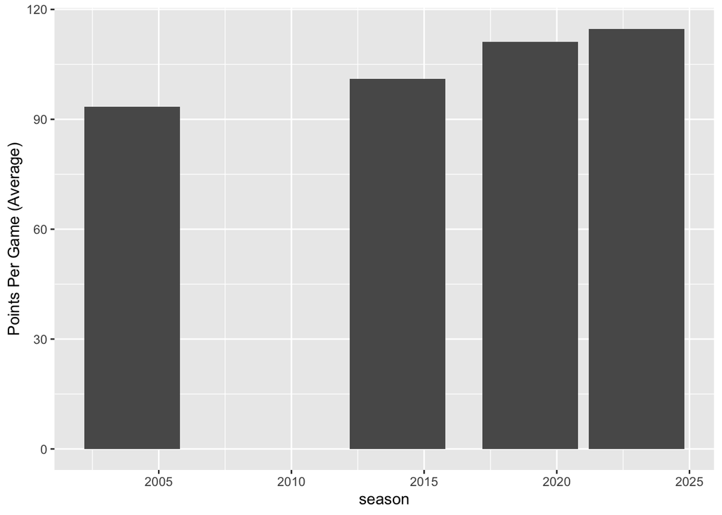

```r
my_team_per_game %>%
  filter(team == "League Average") %>%
  arrange(season) %>%
  select(season, team, pts_per_game) %>%
  ggplot(aes(x = season, y = pts_per_game)) +
  geom_col() +
  scale_y_continuous(name = "Points Per Game (Average)")
```

As we can see, on average over the years, there has been a constant upward to averaging more points as the years have gone by.

If a team is averaging more points per game, it usually means that more shooting opportunities are being created which come from the amount of assists a team has per game. We filter the top teams of each year we are analyzing and doing the same thing as we did for the points scored but instead we want to find out the amount of assists per game.

### 2004 Top 10 Assisting Teams

Here we filter the data of the top 10 teams who had the most amount of assists in 2004.

```r
my_team_per_game %>%
  filter(season == "2004") %>%
  arrange(desc(ast_per_game)) %>%
  head(10) %>%
  select(season, team, abbreviation, ast_per_game)
```

```
##    season                   team abbreviation ast_per_game
## 1    2004       Sacramento Kings          SAC         26.2
## 2    2004        New Jersey Nets          NJN         24.5
## 3    2004       Dallas Mavericks          DAL         23.9
## 4    2004     Los Angeles Lakers          LAL         23.8
## 5    2004      Memphis Grizzlies          MEM         23.4
## 6    2004 Minnesota Timberwolves          MIN         23.0
## 7    2004        Milwaukee Bucks          MIL         22.8
## 8    2004    Cleveland Cavaliers          CLE         22.0
## 9    2004          Chicago Bulls          CHI         21.9
## 10   2004         Denver Nuggets          DEN         21.9
```

### 2014 Top 10 Assisting Teams

Filter the data of the top 10 teams who had the most amount of assists in 2014.

```
##    season                   team abbreviation ast_per_game
## 1    2014      San Antonio Spurs          SAS         25.2
## 2    2014          Atlanta Hawks          ATL         24.9
## 3    2014   Los Angeles Clippers          LAC         24.6
## 4    2014     Los Angeles Lakers          LAL         24.5
## 5    2014 Minnesota Timberwolves          MIN         23.9
## 6    2014       Dallas Mavericks          DAL         23.6
## 7    2014  Golden State Warriors          GSW         23.3
## 8    2014     Washington Wizards          WAS         23.3
## 9    2014 Portland Trail Blazers          POR         23.2
## 10   2014          Chicago Bulls          CHI         22.7
```

### 2019 Top 10 Assisting Teams

Filter the data of the top 10 teams who had the most amount of assists in 2019.

```
##    season                  team abbreviation ast_per_game
## 1    2019 Golden State Warriors          GSW         29.4
## 2    2019        Denver Nuggets          DEN         27.4
## 3    2019  New Orleans Pelicans          NOP         27.0
## 4    2019    Philadelphia 76ers          PHI         26.9
## 5    2019        Boston Celtics          BOS         26.3
## 6    2019    Washington Wizards          WAS         26.3
## 7    2019        Indiana Pacers          IND         26.0
## 8    2019       Milwaukee Bucks          MIL         26.0
## 9    2019             Utah Jazz          UTA         26.0
## 10   2019         Atlanta Hawks          ATL         25.8
```

### 2023 Top 10 Assisting Teams

Filter the data of the top 10 teams who had the most amount of assists in 2023.

```
##    season                   team abbreviation ast_per_game
## 1    2023  Golden State Warriors          GSW         29.8
## 2    2023         Denver Nuggets          DEN         28.9
## 3    2023           Phoenix Suns          PHO         27.3
## 4    2023       Sacramento Kings          SAC         27.3
## 5    2023      San Antonio Spurs          SAS         27.2
## 6    2023         Indiana Pacers          IND         27.0
## 7    2023         Boston Celtics          BOS         26.7
## 8    2023 Minnesota Timberwolves          MIN         26.2
## 9    2023      Memphis Grizzlies          MEM         26.0
## 10   2023              Utah Jazz          UTA         26.0
```

Now let’s take a look at how on overage all teams have changed over the years.

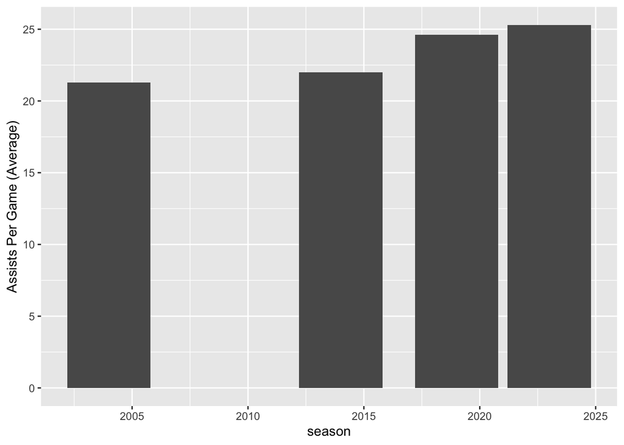

```r
my_team_per_game %>%
  filter(team == "League Average") %>%
  arrange(season) %>%
  select(season, team, ast_per_game) %>%
  ggplot(aes(x = season, y = ast_per_game)) +
  geom_col() +
  scale_y_continuous(name = "Assists Per Game (Average)")
```

With this knowlege we can now see how both point scored and assists are correleated.

```r
my_team_per_game %>%
  filter(team == "League Average") %>%
  arrange(season) %>%
  select(season, team, pts_per_game, ast_per_game)
```

```
##   season           team pts_per_game ast_per_game
## 1   2004 League Average         93.4         21.3
## 2   2014 League Average        101.0         22.0
## 3   2019 League Average        111.2         24.6
## 4   2023 League Average        114.7         25.3
```

With this table, we can see that as the years have gone by, we see about a 20 points increase since 2004, but on average there has only been an increase of 4 assists per game which at most would equal to 12 more points. So where are those extra 8 points from.

We can now take a look at the types of shots that teams attempt. As well as the amount of free throws that teams shoot.

First let’s take a look at the amount of shots taken and broken down into the type of shot. Either a 2-pointer or 3-pointer.

```r
my_team_per_game %>%
  filter(team == "League Average") %>%
  arrange(season) %>%
  select(season, fga_per_game, fg_per_game, x3pa_per_game, x3p_per_game, x2pa_per_game, x2p_per_game)
```

```
##   season fga_per_game fg_per_game x3pa_per_game x3p_per_game x2pa_per_game
## 1   2004         79.8        35.0          14.9          5.2          64.9
## 2   2014         83.0        37.7          21.5          7.7          61.5
## 3   2019         89.2        41.1          32.0         11.4          57.2
## 4   2023         88.3        42.0          34.2         12.3          54.1
##   x2p_per_game
## 1         29.8
## 2         30.0
## 3         29.7
## 4         29.6
```

From this data, we can see that on average, the league now takes about 8 more shots, but take 10 less 2-pointers and 20 more 3-pointers compared to what the league shot in 2004. The league also makes about 3.5 percent more of its shots, yet we only see a 1.4 percent increase in 3-point percentage. Although, we do see a greater increase in the league’s 2-point shot where there is a 8.8 percent increase.

This only explains the change of the type of shots taken.

Now let’s take a look at the change of free throws within the league.

```r
my_team_per_game %>%
  filter(team == "League Average") %>%
  arrange(season) %>%
  select(season, team, fta_per_game, ft_per_game, ft_percent)
```

```
##   season           team fta_per_game ft_per_game ft_percent
## 1   2004 League Average         24.2        18.2      0.752
## 2   2014 League Average         23.6        17.8      0.756
## 3   2019 League Average         23.1        17.7      0.766
## 4   2023 League Average         23.5        18.4      0.782
```

Interestingly, there is a small dip of free throws attempted and about the same amount made and a slight increase in the league’s percentage made. Overall, the league has stayed the same throughout the last 20 years when it comes to the amount attempted and made.

## Individual Player Changes

### Filtered Player Data

Filtering data for the players that played during the 2004, 2014, 2019, or 2023 seasons.

```r
my_player_per_game <- player_per_game %>%
  filter(season == "2004" | season == "2014" | season == "2019" | season == "2023")
```

Here we can see all of the players that averaged more than 20 points per game during the 2004 Season. If a player was traded during the season, that player would appear for however many teams he played for in that seasons and an average for the whole season. In this case, “Stephon Marbury” had to be removed for when he played for Pheonix. Withing the graph we can see that the majority of players that averaged 20 or more points were Shooting Guards and Power Forwards.

### Players that averaged 20 or more points in 2004

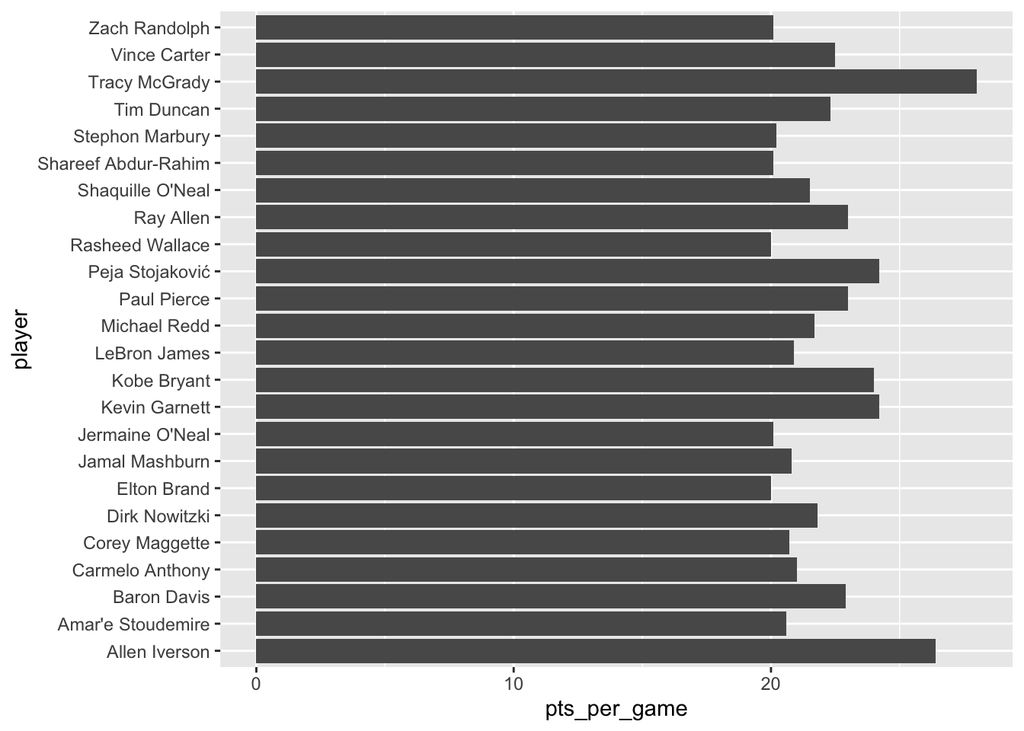

```r
my_player_per_game %>%
  filter(season == "2004" & pts_per_game >= 20) %>%
  filter(player != "Stephon Marbury" | tm != "PHO") %>%
  ggplot(aes(x = player, y = pts_per_game)) +
  geom_col() +
  coord_flip()
```

Here we have the total number of players that averaged 20 or more points in the 2004 season and categorized by the players’ position. The data again had to be filtered to only show their averages for that season instead of each individual team that they played for if they were traded during the season.

### Amount of plavers that scored 20 or more points in 2004 by position

```
## # A tibble: 5 × 2
##   pos   player
##   <chr>  <int>
## 1 C          2
## 2 PF         8
## 3 PG         2
## 4 SF         4
## 5 SG         8
```

Now we can look at the same data but for the rest of the years.

### Players that averaged 20 or more points in 2014

From the filtered data that we are working with, for the 2014 season, we see our first player that averaged 30 or more points.

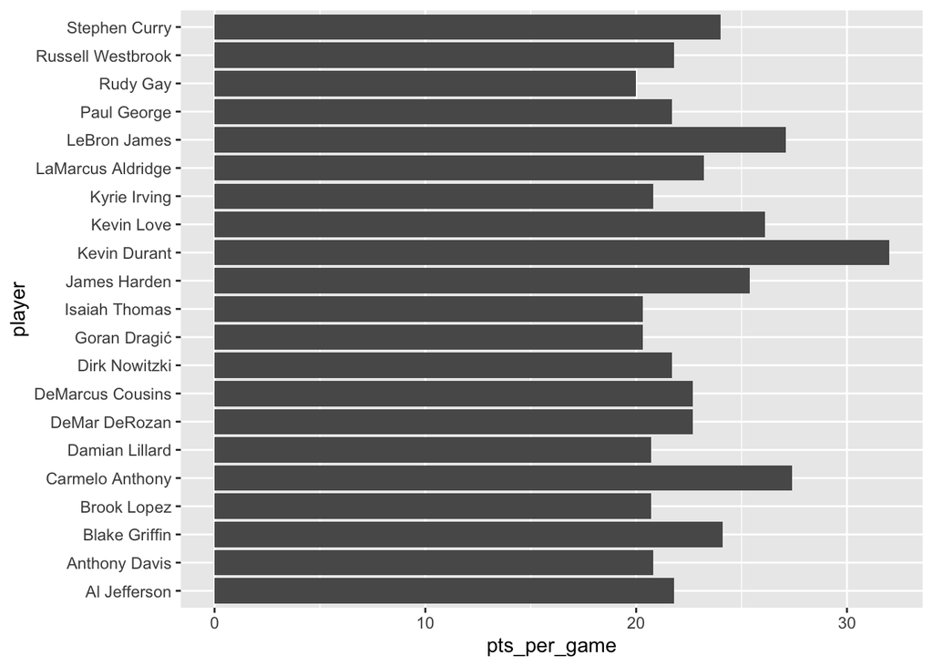

```r
my_player_per_game %>%
  filter(season == "2014" & pts_per_game >= 20) %>%
  filter(player != "Rudy Gay" | tm != "SAC") %>%
  ggplot(aes(x = player, y = pts_per_game)) +
  geom_col() +
  coord_flip()
```

### Amount of plavers that scored 20 or more points in 2014 by position

```
## # A tibble: 5 × 2
##   pos   player
##   <chr>  <int>
## 1 C          3
## 2 PF         7
## 3 PG         5
## 4 SF         3
## 5 SG         3
```

### Amount of plavers that scored 30 or more points in 2014 by position

```
## # A tibble: 1 × 2
##   pos   player
##   <chr>  <int>
## 1 SF         1
```

### Players that averaged 20 or more points in 2019

For the 2019 season, not only do we find another player that average 30 points. He also averaged 35 or more during the season.

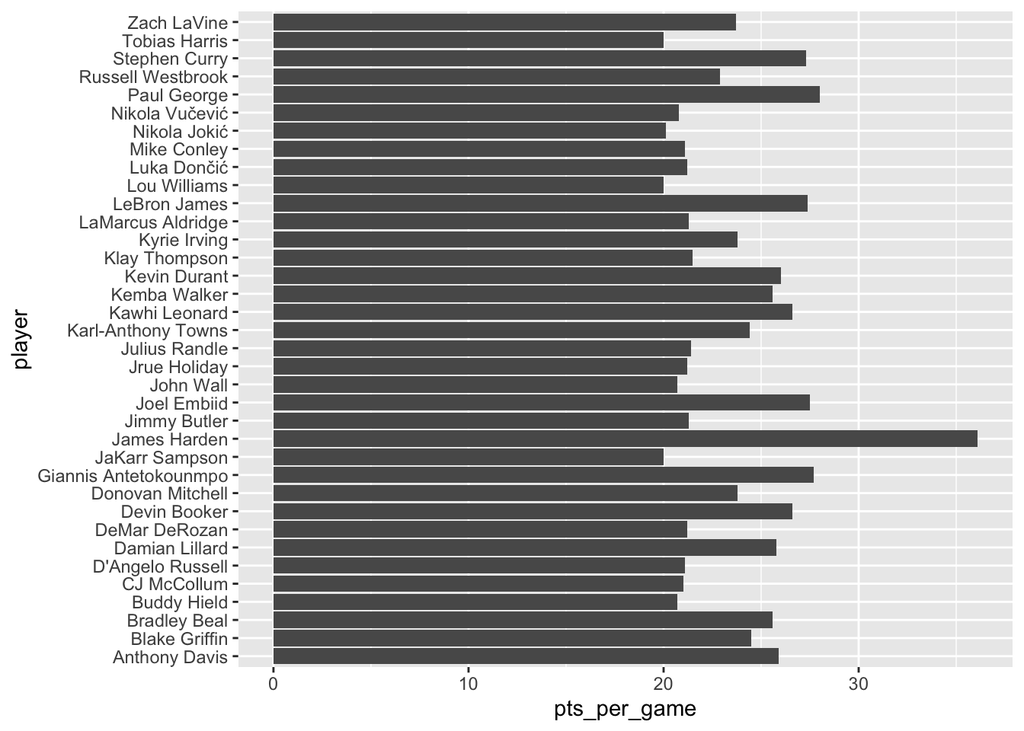

```r
my_player_per_game %>%
  filter(season == "2019" & pts_per_game >= 20) %>%
  filter(player != "Tobias Harris" | tm != "LAC") %>%
  ggplot(aes(x = player, y = pts_per_game)) +
  geom_col() +
  coord_flip()
```

### Amount of plavers that scored 20 or more points in 2019 by position

```
## # A tibble: 5 × 2
##   pos   player
##   <chr>  <int>
## 1 C          6
## 2 PF         4
## 3 PG         9
## 4 SF         5
## 5 SG        12
```

### Amount of plavers that scored 30 or more points in 2019 by position

```
## # A tibble: 1 × 2
##   pos   player
##   <chr>  <int>
## 1 PG         1
```

### Amount of plavers that scored 35 or more points in 2019 by position

```
## # A tibble: 1 × 2
##   pos   player
##   <chr>  <int>
## 1 PG         1
```

### Players that averaged 20 or more points in 2023

Here we find that we have an abundance of players that scored 20 or more points last year. There were so many that scored 20 points that there were a total of 20 players that scored 25 or more points. Compare that to in 2004 we found that there were only 24 players total who scored 20 or more.

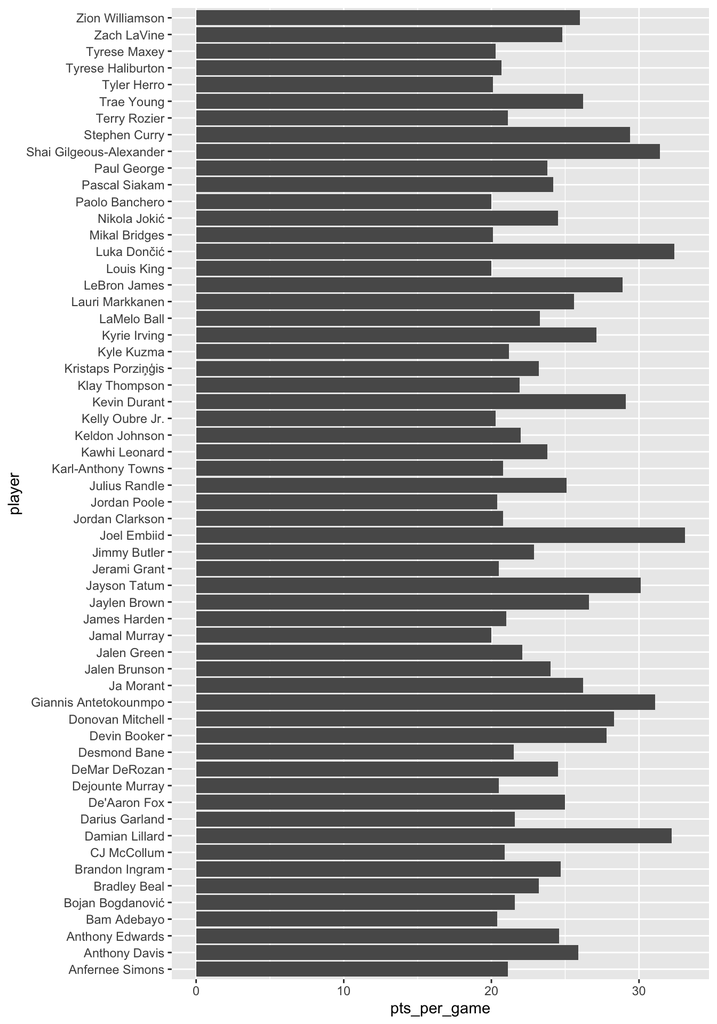

```r
my_player_per_game %>%
  filter(season == "2023" & pts_per_game >= 20) %>%
  filter(player != "Kevin Durant" | (tm != "BRK" & tm != "PHO")) %>%
  filter(player != "Kyrie Irving" | (tm != "BRK" & tm != "DAL")) %>%
  filter(player != "Mikal Bridges" | tm != "BRK") %>%
  ggplot(aes(x = player, y = pts_per_game)) +
  geom_col() +
  coord_flip()
```

### Amount of plavers that scored 20 or more points in 2023 by position

```
## # A tibble: 6 × 2
##   pos   player
##   <chr>  <int>
## 1 C          6
## 2 PF        10
## 3 PF-SF      1
## 4 PG        15
## 5 SF        10
## 6 SG        16
```

#### Amount of players that scored 25 or more points in 2023 by position

```
## # A tibble: 6 × 2
##   pos   player
##   <chr>  <int>
## 1 C          2
## 2 PF         5
## 3 PF-SF      1
## 4 PG         8
## 5 SF         2
## 6 SG         2
```

#### Amount of players that scored 30 or more points in 2023 by position

```
## # A tibble: 3 × 2
##   pos   player
##   <chr>  <int>
## 1 C          1
## 2 PF         2
## 3 PG         3
```

## Conlusion

In conclusion, there has a been a major shift in the amount of points that teams make and the pace at which they make those points. Since more points are being scored, there is also a slight increase in the amount of assists that teams average. This can then lead to the increase amount of players that average more points to the amount we saw back in 2004. With the increase of pace from the teams, this leads to more chances of an individual being able to score and with the help of the increase of 3-pointers being shot. It is no surprise that more players are scoring higher than the players in 2004 did.